# Predict Bike Sharing Demand with AutoGluon

### Create Predictions → Check Negatives → Save submission.csv

```python
X_test_init = test.drop(columns=['datetime'])
predictions = predictor.predict(X_test_init)

# Describe to check for negatives
pd.Series(predictions).describe()
```

```
count    6493.000000
mean      193.853962
std       123.712565
min         5.469996
25%        95.593531
50%       167.780516
75%       272.990333
max       704.480717
dtype: float64
```

```python
# How many negative values?
print((predictions < 0).sum(), 'negative predictions')

# Kaggle rejects count < 0 — clip to zero
predictions = np.maximum(0, predictions)

# Save submission.csv — update if file already exists, create if it doesn't
output_path = 'submission.csv'
submission['count'] = predictions

if os.path.exists(output_path):
    print(f'File "{output_path}" already exists — overwriting with updated predictions.')
else:
    print(f'File "{output_path}" not found — creating new file.')

submission.to_csv(output_path, index=False)
print(f'Saved → {output_path}')
submission.head()
```

```
0 negative predictions
File "submission.csv" already exists — overwriting with updated predictions.
Saved → submission.csv
```

|  | datetime | count |
| --- | --- | --- |
| 0 | 2011-01-20 00:00:00 | 168.636907 |
| 1 | 2011-01-20 01:00:00 | 61.538385 |
| 2 | 2011-01-20 02:00:00 | 61.538385 |
| 3 | 2011-01-20 03:00:00 | 115.882686 |
| 4 | 2011-01-20 04:00:00 | 115.882686 |

#### Initial Kaggle Score: `0.48254` | Val RMSE: `150.96`

### 💬 Observation — Initial Training

**What did you realize when you tried to submit your predictions? What changes were needed?**

Two adjustments were required before submission:

1. **Exclude `casual` and `registered`** — present in train but absent in test; causes a feature-mismatch error at inference.
2. **Clip predictions to zero** — `predictions = np.maximum(0, predictions)`. Kaggle rejects `count < 0`.

The initial val RMSE of **150.96** is high because the raw `datetime` column is dropped entirely, so the model has no access to hour-of-day — the single most important demand driver.

**What was the top ranked model?**

`RandomForestRegressor` (n_estimators=500, max_depth=20). Without temporal features, the model relies on weather/humidity signals (importance: humidity 26%, atemp 23%, windspeed 20%).

## Step 4: Exploratory Data Analysis and Creating Additional Features

```python
# Combine train + test for joint feature engineering then split back
df = pd.concat([train, test], axis=0, ignore_index=True)
print(f'Combined shape: {df.shape}')
df.info()
```

```
Combined shape: (17379, 12)
<class 'pandas.core.frame.DataFrame'>
RangeIndex: 17379 entries, 0 to 17378
Data columns (total 12 columns):
 #   Column      Non-Null Count  Dtype
---  ------      --------------  -----
 0   datetime    17379 non-null  datetime64[ns]
 1   season      17379 non-null  int64
 2   holiday     17379 non-null  int64
 3   workingday  17379 non-null  int64
 4   weather     17379 non-null  int64
 5   temp        17379 non-null  float64
 6   atemp       17379 non-null  float64
 7   humidity    17379 non-null  int64
 8   windspeed   17379 non-null  float64
 9   casual      10886 non-null  float64
 10  registered  10886 non-null  float64
 11  count       10886 non-null  float64
dtypes: datetime64[ns](1), float64(6), int64(5)
memory usage: 1.6 MB
```

```python
df.describe()
```

|  | datetime | season | holiday | workingday | weather | temp | atemp | humidity | windspeed | casual | registered | count |
| --- | --- | --- | --- | --- | --- | --- | --- | --- | --- | --- | --- | --- |
| count | 17379 | 17379.000000 | 17379.000000 | 17379.000000 | 17379.000000 | 17379.000000 | 17379.000000 | 17379.000000 | 17379.000000 | 10886.000000 | 10886.000000 | 10886.000000 |
| mean | 2012-01-02 15:41:22.858622464 | 2.501640 | 0.028770 | 0.682721 | 1.425283 | 20.376474 | 23.788755 | 62.722884 | 12.736540 | 36.021955 | 155.552177 | 191.574132 |
| min | 2011-01-01 00:00:00 | 1.000000 | 0.000000 | 0.000000 | 1.000000 | 0.820000 | 0.000000 | 0.000000 | 0.000000 | 0.000000 | 0.000000 | 1.000000 |
| 25% | 2011-07-04 22:30:00 | 2.000000 | 0.000000 | 0.000000 | 1.000000 | 13.940000 | 16.665000 | 48.000000 | 7.001500 | 4.000000 | 36.000000 | 42.000000 |
| 50% | 2012-01-02 21:00:00 | 3.000000 | 0.000000 | 1.000000 | 1.000000 | 20.500000 | 24.240000 | 63.000000 | 12.998000 | 17.000000 | 118.000000 | 145.000000 |
| 75% | 2012-07-02 06:30:00 | 3.000000 | 0.000000 | 1.000000 | 2.000000 | 27.060000 | 31.060000 | 78.000000 | 16.997900 | 49.000000 | 222.000000 | 284.000000 |
| max | 2012-12-31 23:00:00 | 4.000000 | 1.000000 | 1.000000 | 4.000000 | 41.000000 | 50.000000 | 100.000000 | 56.996900 | 367.000000 | 886.000000 | 977.000000 |
| std | NaN | 1.106918 | 0.167165 | 0.465431 | 0.639357 | 7.894801 | 8.592511 | 19.292983 | 8.196795 | 49.960477 | 151.039033 | 181.144454 |

```python
# Missing values — the 6 493 NaNs in count/casual/registered are intentional:
# they are the test-set rows whose target we must predict.
df.isnull().sum()
```

```
datetime         0
season           0
holiday          0
workingday       0
weather          0
temp             0
atemp            0
humidity         0
windspeed        0
casual        6493
registered    6493
count         6493
dtype: int64
```

The 6,493 NaN values in `count`, `casual`, and `registered` are from the **test set** — they are the targets we need to predict, not a data quality issue.

### EDA: Feature Distributions (Before Engineering)

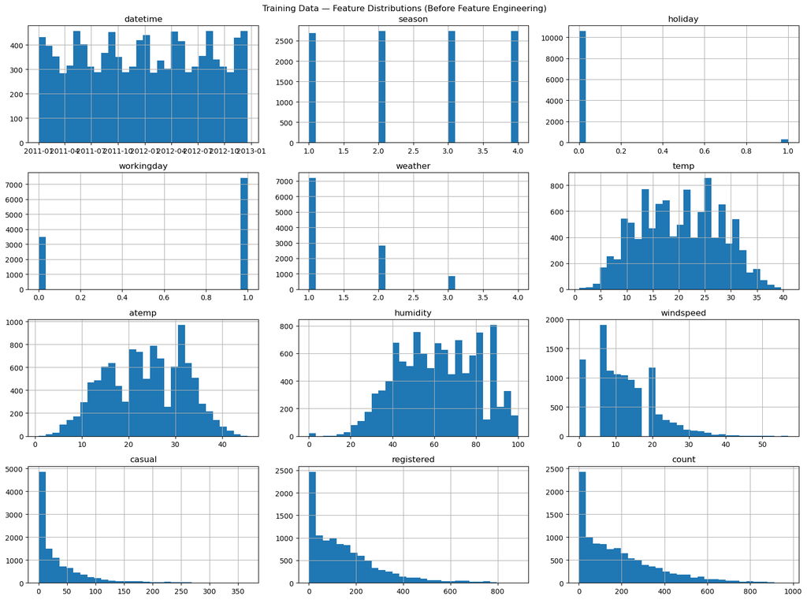

```
Saved img/eda_histograms_before.png
```

```python
os.makedirs('img', exist_ok=True)

train.hist(bins=30, figsize=(16, 12))
plt.suptitle('Training Data — Feature Distributions (Before Feature Engineering)')
plt.tight_layout()
plt.savefig('img/eda_histograms_before.png', dpi=100)
plt.show()
print('Saved img/eda_histograms_before.png')
```

### EDA Chart 1: Weekly Rental Patterns — 2011 vs 2012

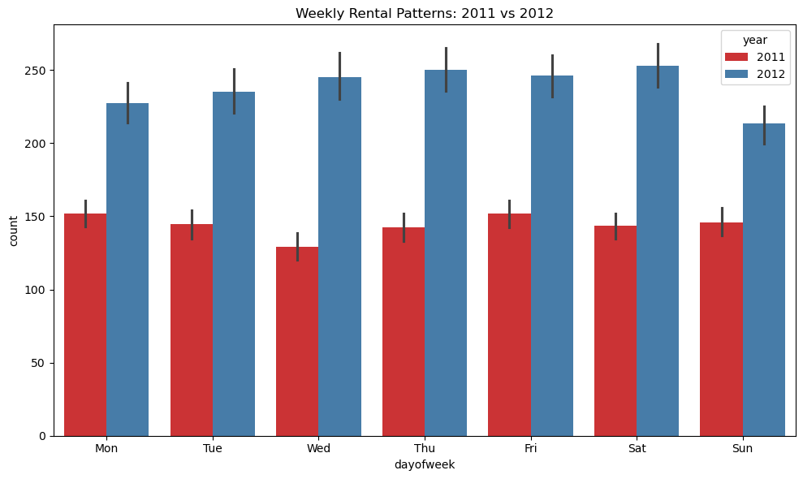

```
Saved img/eda_weekly_patterns.png
```

```python
# EDA Chart 1: Weekly Rental Patterns — reuse `train` directly (already loaded, already datetime)
_train_weekly = train.copy()
_train_weekly['year']      = _train_weekly['datetime'].dt.year
_train_weekly['dayofweek'] = _train_weekly['datetime'].dt.dayofweek

fig, ax = plt.subplots(figsize=(10, 6))
sns.barplot(data=_train_weekly, x='dayofweek', y='count', hue='year',
            palette='Set1', ax=ax)
ax.set_xticks(range(7))
ax.set_xticklabels(['Mon', 'Tue', 'Wed', 'Thu', 'Fri', 'Sat', 'Sun'])
ax.set_title('Weekly Rental Patterns: 2011 vs 2012')
plt.tight_layout()
plt.savefig('img/eda_weekly_patterns.png', dpi=100)
plt.show()
print('Saved img/eda_weekly_patterns.png')
```

### EDA Chart 2: Rental Demand by Weather Condition

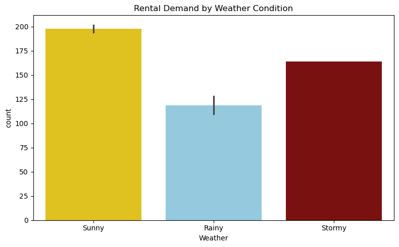

```
Saved img/eda_weather_demand.png
```

```python
# Build _train_eda: EDA DataFrame with temporal + weather features
# datetime already parsed by read_csv(parse_dates=), no re-parse needed
_df_eda = pd.concat([train, test], ignore_index=True).copy()
_df_eda['hour']      = _df_eda['datetime'].dt.hour
_df_eda['year']      = _df_eda['datetime'].dt.year
_df_eda['dayofweek'] = _df_eda['datetime'].dt.dayofweek
_df_eda['month']     = _df_eda['datetime'].dt.month

# One-hot encode season and weather (drop_first removes season_1 / weather_1 as baseline)
_df_eda = pd.get_dummies(_df_eda, columns=['season', 'weather'], drop_first=True)

# Rename dummies — errors='ignore' is safe if weather_4 doesn't appear in the data
_df_eda.rename(columns={
    'weather_2': 'cloudy',
    'weather_3': 'rainy',
    'weather_4': 'heavy_storm'
}, errors='ignore', inplace=True)

_train_eda = _df_eda[_df_eda['count'].notnull()].copy()

# Build a numeric weather severity label for the bar chart
_train_eda['Weather'] = (
    _train_eda.get('rainy', 0).astype(int) +
    _train_eda.get('heavy_storm', 0).astype(int) * 2
)

fig, ax = plt.subplots(figsize=(8, 5))
sns.barplot(data=_train_eda, x='Weather', y='count',
            palette=['gold', 'skyblue', 'darkred'], ax=ax)
ax.set_xticks([0, 1, 2])
ax.set_xticklabels(['Sunny', 'Rainy', 'Stormy'])
ax.set_title('Rental Demand by Weather Condition')
plt.tight_layout()
plt.savefig('img/eda_weather_demand.png', dpi=100)
plt.show()
print('Saved img/eda_weather_demand.png')
```

### EDA Chart 3: Hourly Demand — Working Days vs Weekends

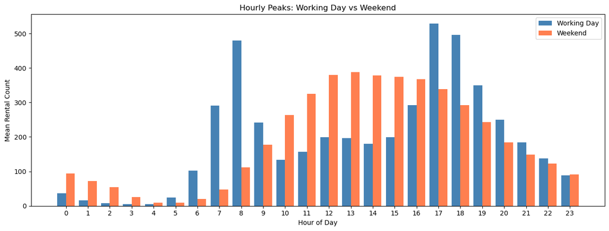

```
Saved img/eda_hourly_peaks.png
```

```python
# Hourly demand: working day vs weekend
hourly = _train_eda.groupby(['hour', 'workingday'])['count'].mean().reset_index()
wd  = hourly[hourly['workingday'] == 1].set_index('hour').reindex(range(24))['count'].fillna(0)
wkd = hourly[hourly['workingday'] == 0].set_index('hour').reindex(range(24))['count'].fillna(0)

x = np.arange(24)
fig, ax = plt.subplots(figsize=(13, 5))
ax.bar(x - 0.2, wd,  width=0.4, label='Working Day', color='steelblue')
ax.bar(x + 0.2, wkd, width=0.4, label='Weekend',     color='coral')
ax.set_xticks(x)
ax.set_xticklabels(range(24))
ax.set(title='Hourly Peaks: Working Day vs Weekend',
       xlabel='Hour of Day', ylabel='Mean Rental Count')
ax.legend()
plt.tight_layout()
plt.savefig('img/eda_hourly_peaks.png', dpi=150)
plt.show()
print('Saved img/eda_hourly_peaks.png')
```

Working days show two sharp peaks at **8 AM** and **5–6 PM** (commuter trips). Weekends have a broad leisure plateau from 10 AM–6 PM. This makes `hour` the most powerful single feature we can engineer.